# Lab 8: MATH 4753

Justin Kleiber

2019-10-14

# Task 1

First, the working directory is confirmed

```r
getwd()
```

```
## [1] "C:/Users/jklei/Desktop/Projects/MATH4753/Lab8"
```

# Task 2

Random uniform sample of size 10:

```r
unif = runif(10, 0, 5)
unif
```

```
##  [1] 1.1244633 3.7404033 0.4345583 4.5485577 2.3529007 3.3692685 2.8456258
##  [8] 3.8465654 4.0204978 0.1048277
```

Mean and variance of a uniform with a = 0, b = 5:
$$\mu = \frac{a+b}{2} = \frac{5}{2} = 2.5\\
\sigma^2 = \frac{(b-a)^2}{12} = \frac{25}{12} = 2.083333$$

Mean and variance of this sample

```r
mean(unif)
```

```
## [1] 2.638767
```

```r
var(unif)
```

```
## [1] 2.4955
```

The mean and variance of the sample are close to the calculated values for the distribution.

$T = Y_1 + Y_2 + ... + Y_n$ so T =

```r
T = sum(unif)
T
```

```
## [1] 26.38767
```

and $\bar{Y} = \frac{T}{n}$ so $\bar{Y}$ =

```r
Ybar = T / 10
Ybar
```

```
## [1] 2.638767
```

The function myclt is below, with key lines marked

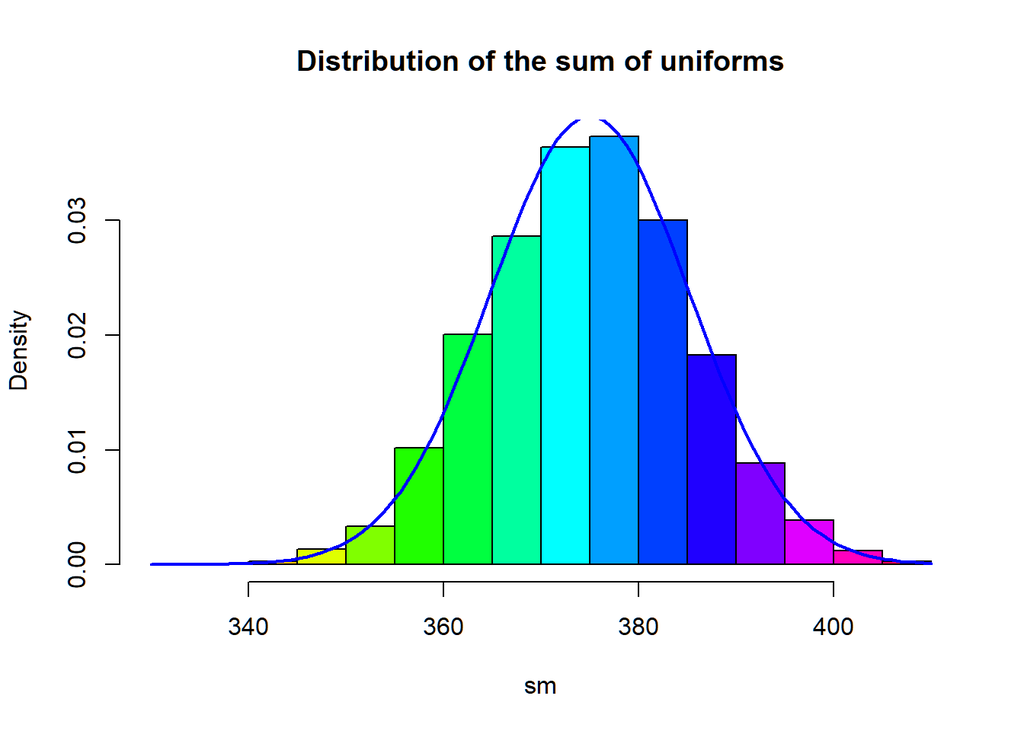

```r
myclt=function(n,iter,a=0,b=5){
  y=runif(n*iter,a,b) #A
  data=matrix(y,nr=n,nc=iter,byrow=TRUE) #B
  sm=apply(data,2,sum) #C
  h=hist(sm,plot=FALSE)
  hist(sm,col=rainbow(length(h$mids)),freq=FALSE,main="Distribution of the sum of uniforms")
  curve(dnorm(x,mean=n*(a+b)/2,sd=sqrt(n*(b-a)^2/12)),add=TRUE,lwd=2,col="Blue")
  sm
}
w=myclt(n=50,iter=10000,a=5,b=10) #D
```

where line A creates a random uniform sample that will be split into `iter` samples of size `n`, B creates a matrix and splits the sample, C creates a margin on the columns for the sum of the rows. Finally, D executes the function, and the plot is shown above.

The estimates for mean and variance of the sample are calculated below:

```r
mean(w)
```

```
## [1] 374.8522
```

```r
var(w)
```

```
## [1] 107.1038
```

A new version of `myclt` is below for plotting sample means:

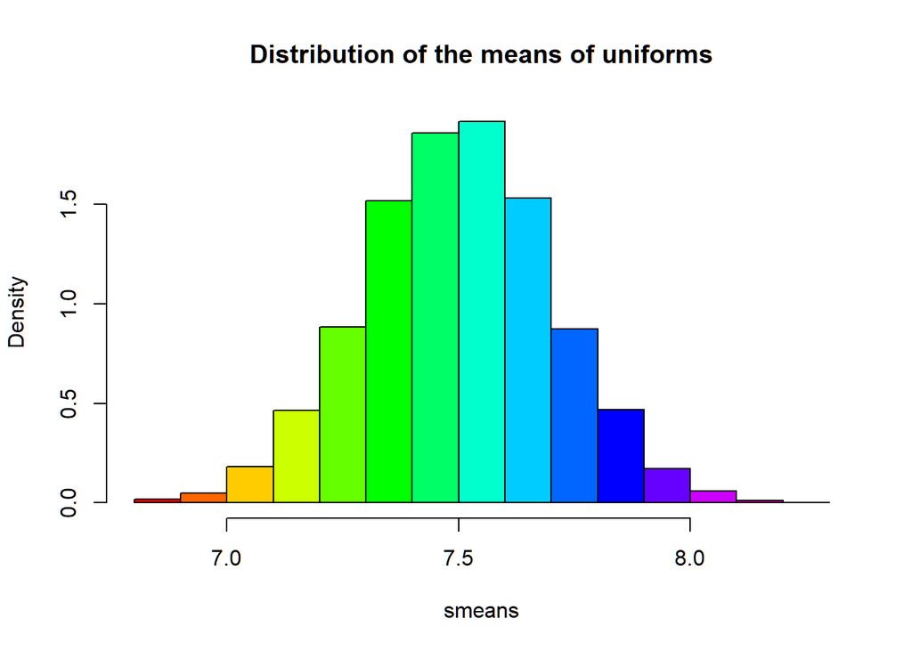

```r
myclt=function(n,iter,a=0,b=5){
  y=runif(n*iter,a,b) #A
  data=matrix(y,nr=n,nc=iter,byrow=TRUE) #B
  smeans=apply(data,2,mean) #C
  h=hist(smeans,plot=FALSE)
  hist(smeans,col=rainbow(length(h$mids)),freq=FALSE,main="Distribution of the means of uniforms")
  smeans
}
w2=myclt(n=50,iter=10000,a=5,b=10) #D
```

```r
mean(w2)
```

```
## [1] 7.500012
```

```r
var(w2)
```

```
## [1] 0.0407933
```

# Task 3

A more advanced function, `mycltu` is shown below:

```r
mycltu=function(n,iter,a=0,b=10){
  ## r-random sample from the uniform
  y=runif(n*iter,a,b)
  ## Place these numbers into a matrix
  ## The columns will correspond to the iteration and the rows will equal the sample size n
  data=matrix(y,nr=n,nc=iter,byrow=TRUE)
  ## apply the function mean to the columns (2) of the matrix
  ## these are placed in a vector w
  w=apply(data,2,mean)
  ## We will make a histogram of the values in w
  ## How high should we make y axis?
  ## All the values used to make a histogram are placed in param (nothing is plotted yet)
  param=hist(w,plot=FALSE)
  ## Since the histogram will be a density plot we will find the max density

  ymax=max(param$density)
  ## To be on the safe side we will add 10% more to this
  ymax=1.1*ymax
  ## Now we can make the histogram
  hist(w,freq=FALSE,  ylim=c(0,ymax), main=paste("Histogram of sample mean",
  "\n", "sample size= ",n,sep=""),xlab="Sample mean")
  ## add a density curve made from the sample distribution
  lines(density(w),col="Blue",lwd=3) # add a density plot
  ## Add a theoretical normal curve
  curve(dnorm(x,mean=(a+b)/2,sd=(b-a)/(sqrt(12*n))),add=TRUE,col="Red",lty=2,lwd=3) # add a   theoretical curve
  ## Add the density from which the samples were taken
  curve(dunif(x,a,b),add=TRUE,lwd=4)
}
```

Plot n=1

```r
p1 = mycltu(1, 10000, a=0, b=10)
```

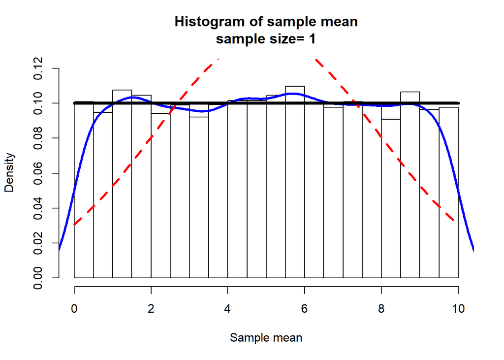

Plot n=2

```r
p2 = mycltu(2, 10000, a=0, b=10)
```

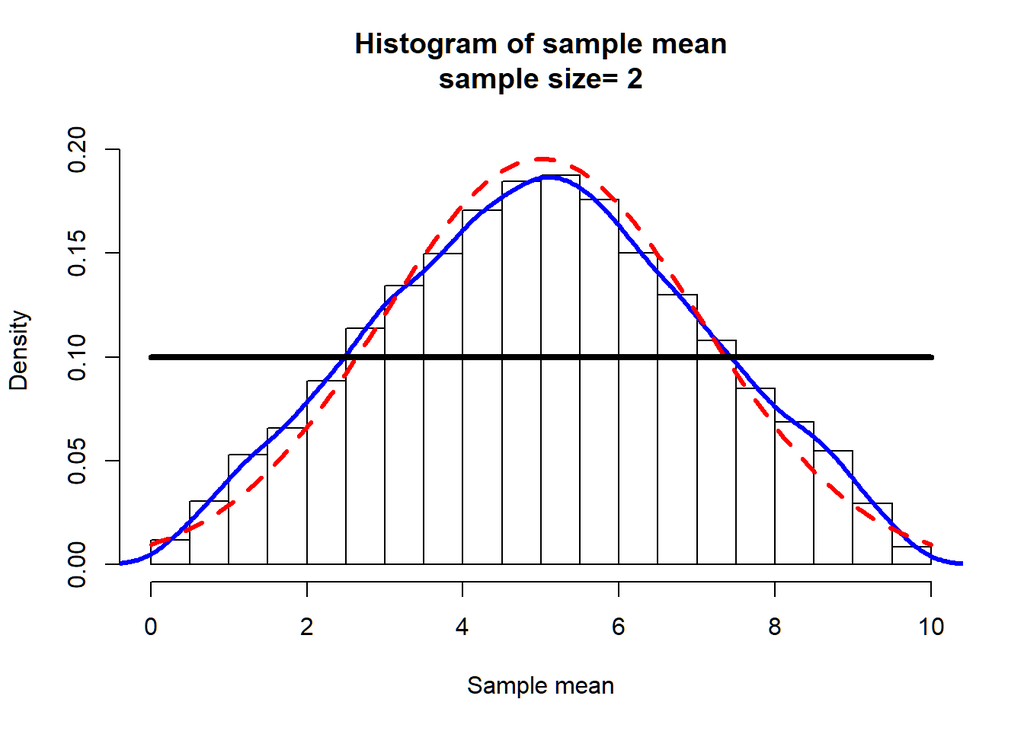

Plot n=3

```r
p3 = mycltu(3, 10000, a=0, b=10)
```

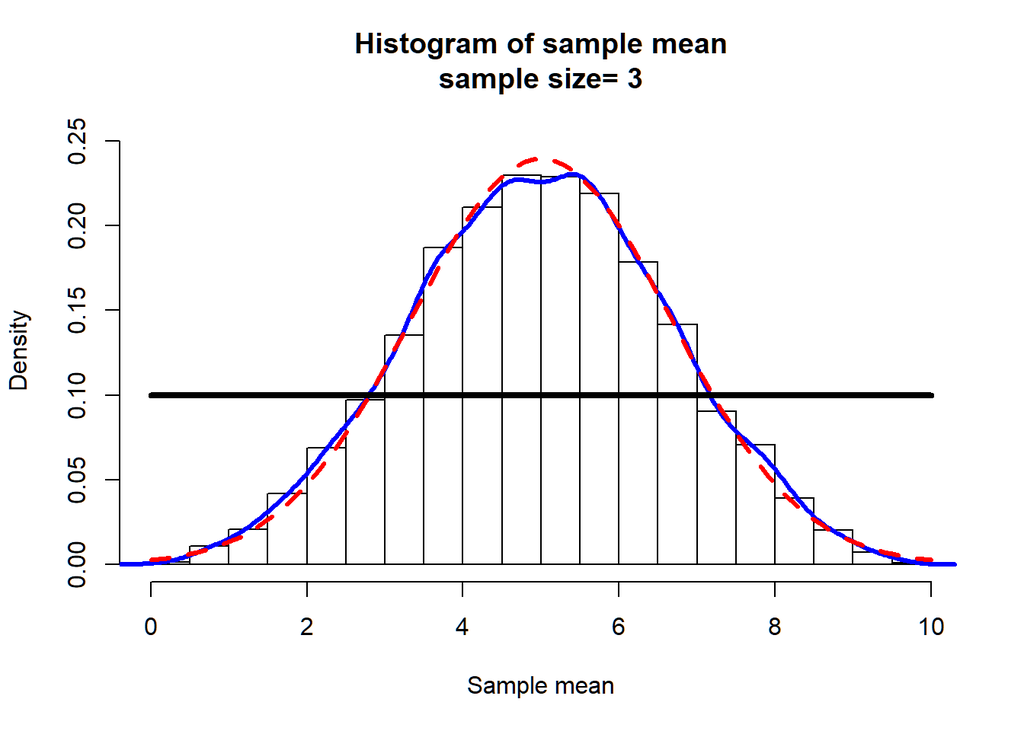

Plot n=5

```r
p5 = mycltu(5, 10000, a=0, b=10)
```

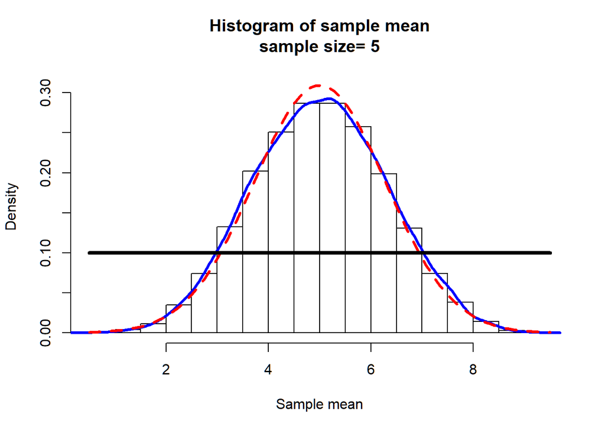

Plot n=10

```r
p10 = mycltu(10, 10000, a=0, b=10)
```

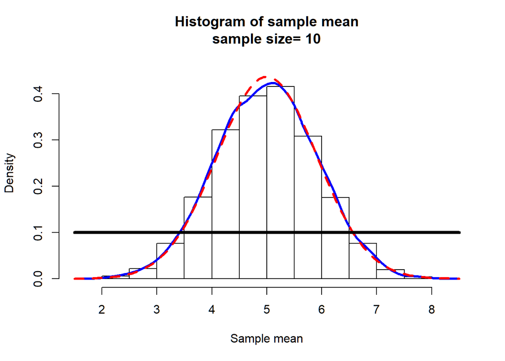

Plot n=30

```r
p30 = mycltu(30, 10000, a=0, b=10)
```

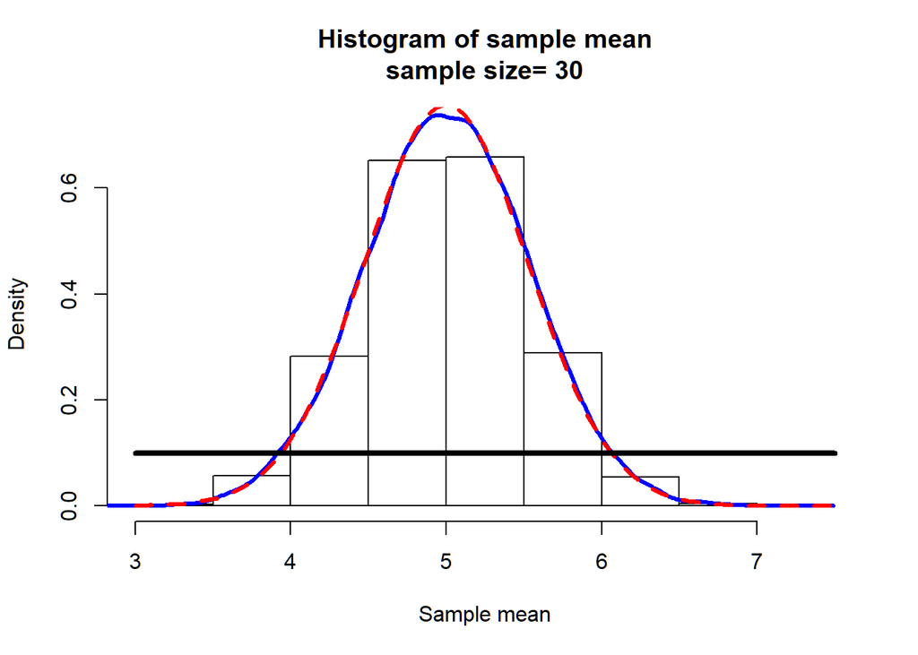

As n increases, the histogram looks more like a normal distribution.

# Task 4

A new function for binomial sampling is below, called `mycltb`:

```r
mycltb=function(n,iter,p=0.5,...){
  ## r-random sample from the Binomial
  y=rbinom(n*iter,size=n,prob=p)
  ## Place these numbers into a matrix
  ## The columns will correspond to the iteration and the rows will equal the sample size n
  data=matrix(y,nr=n,nc=iter,byrow=TRUE)
  ## apply the function mean to the columns (2) of the matrix
  ## these are placed in a vector w
  w=apply(data,2,mean)
  ## We will make a histogram of the values in w
  ## How high should we make y axis?
  ## All the values used to make a histogram are placed in param (nothing is plotted yet)
  param=hist(w,plot=FALSE)
  ## Since the histogram will be a density plot we will find the max density

  ymax=max(param$density)
  ## To be on the safe side we will add 10% more to this
  ymax=1.1*ymax

  ## Now we can make the histogram
  ## freq=FALSE means take a density
  hist(w,freq=FALSE,  ylim=c(0,ymax),
  main=paste("Histogram of sample mean","\n", "sample size= ",n,sep=""),
  xlab="Sample mean",...)
  ## add a density curve made from the sample distribution
  #lines(density(w),col="Blue",lwd=3) # add a density plot
  ## Add a theoretical normal curve
  curve(dnorm(x,mean=n*p,sd=sqrt(p*(1-p))),add=TRUE,col="Red",lty=2,lwd=3)
}
```

### Probabilities of 0.3

Graph for n=4:

```r
b4 = mycltb(4, 10000, 0.3)
```

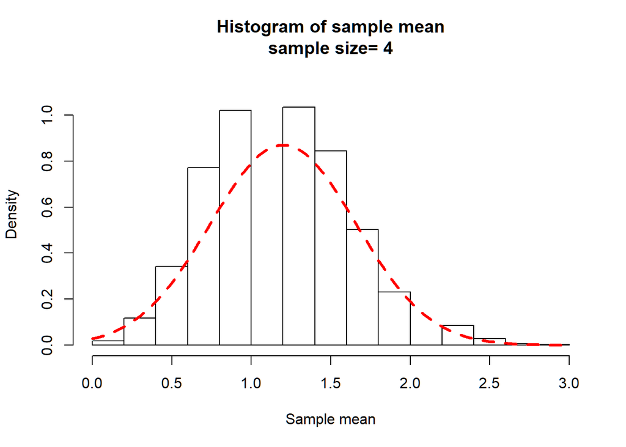

Graph for n=5:

```r
b5 = mycltb(5, 10000, 0.3)
```

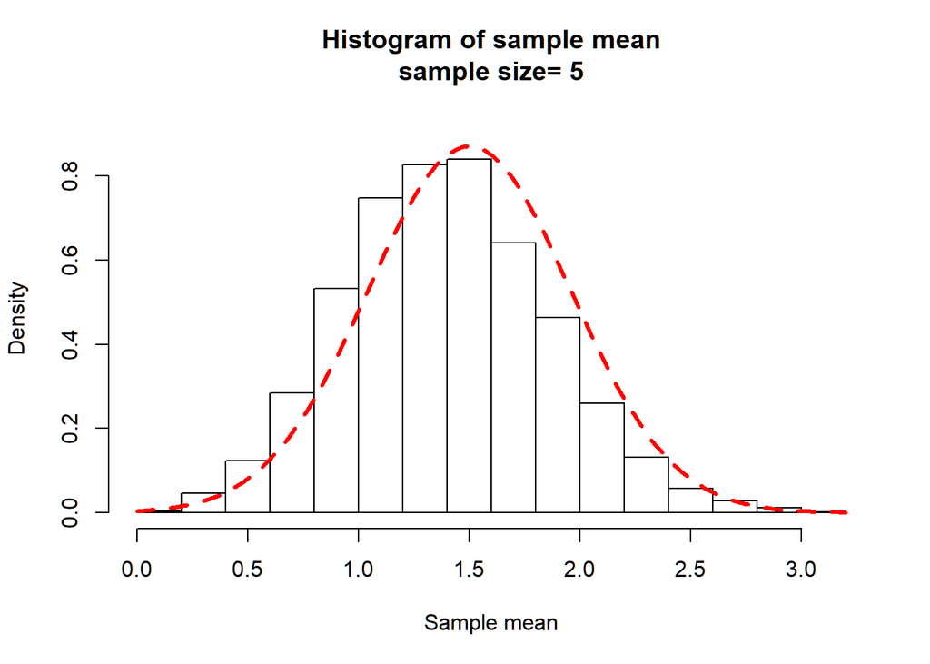

Graph for n=10:

```r
b10 = mycltb(10, 10000, 0.3)
```

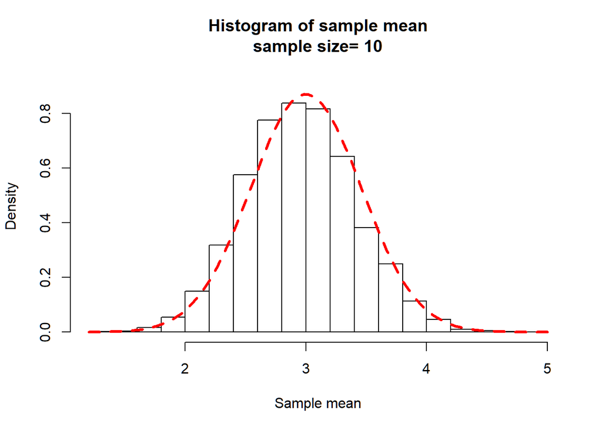

Graph for n=20:

```r
b20 = mycltb(20, 10000, 0.3)
```

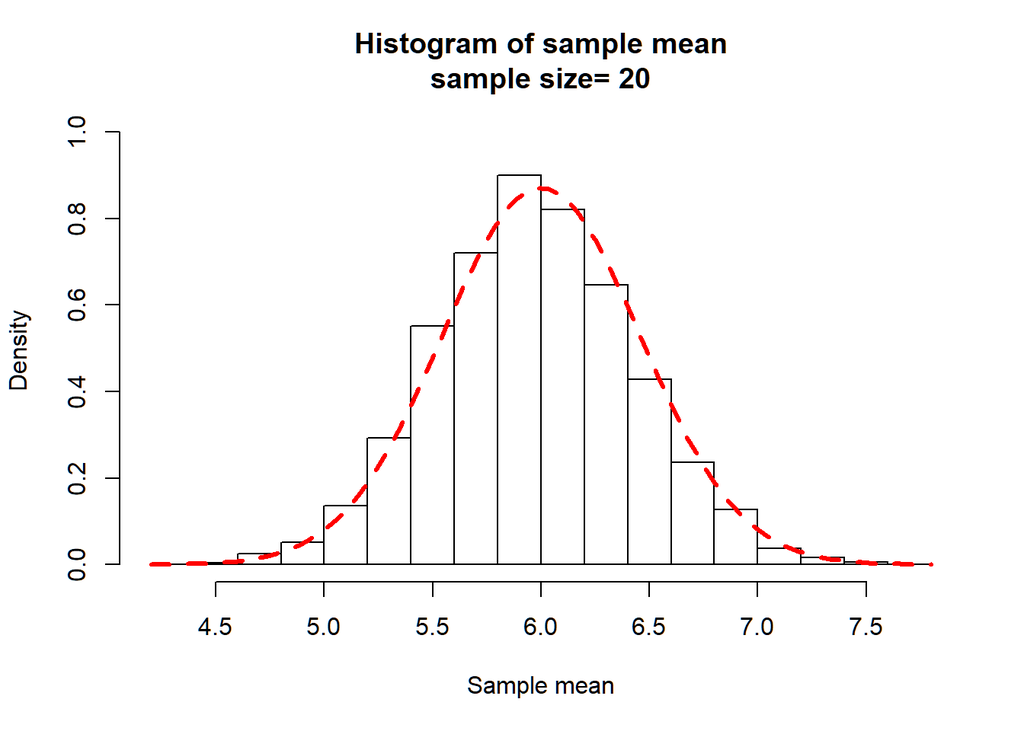

### Probabilities of 0.7

Graph for n=4:

```r
b4 = mycltb(4, 10000, 0.7)
```

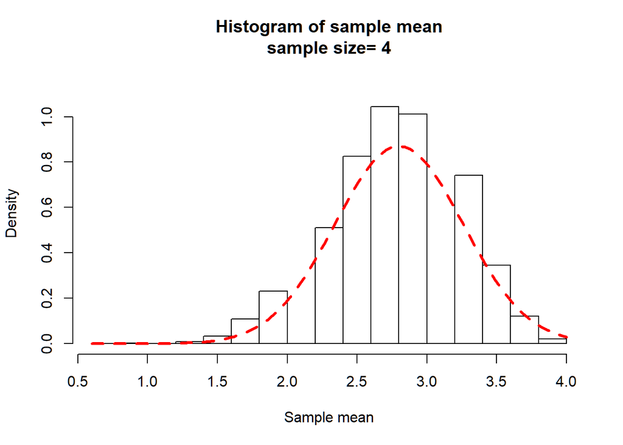

Graph for n=5:

```r
b5 = mycltb(5, 10000, 0.7)
```

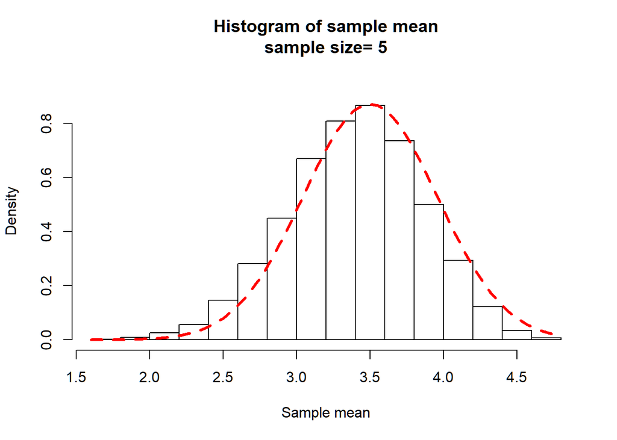

Graph for n=10:

```r
b10 = mycltb(10, 10000, 0.7)
```

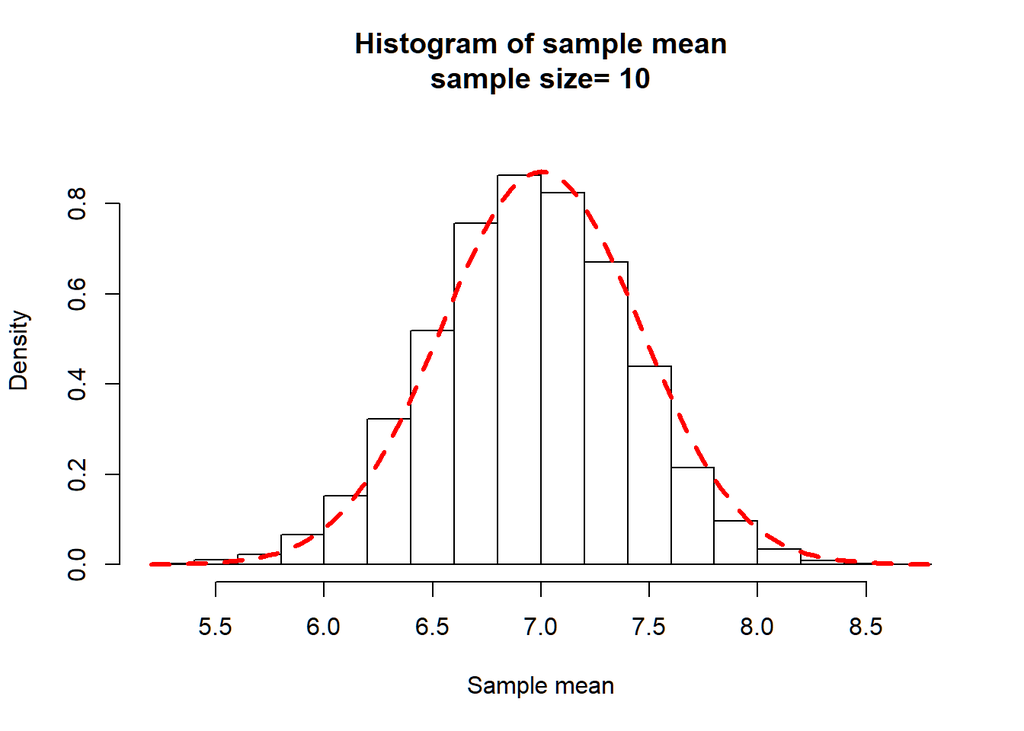

Graph for n=20:

```r
b20 = mycltb(20, 10000, 0.7)
```

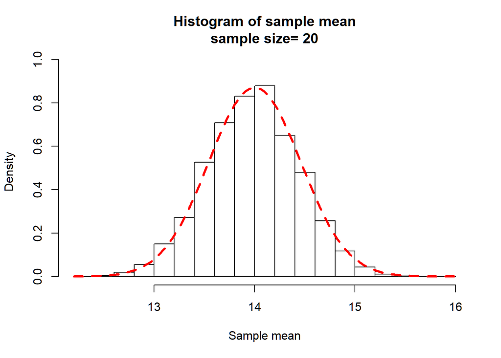

### Probabilities of 0.5

Graph for n=4:

```r
b4 = mycltb(4, 10000, 0.5)
```

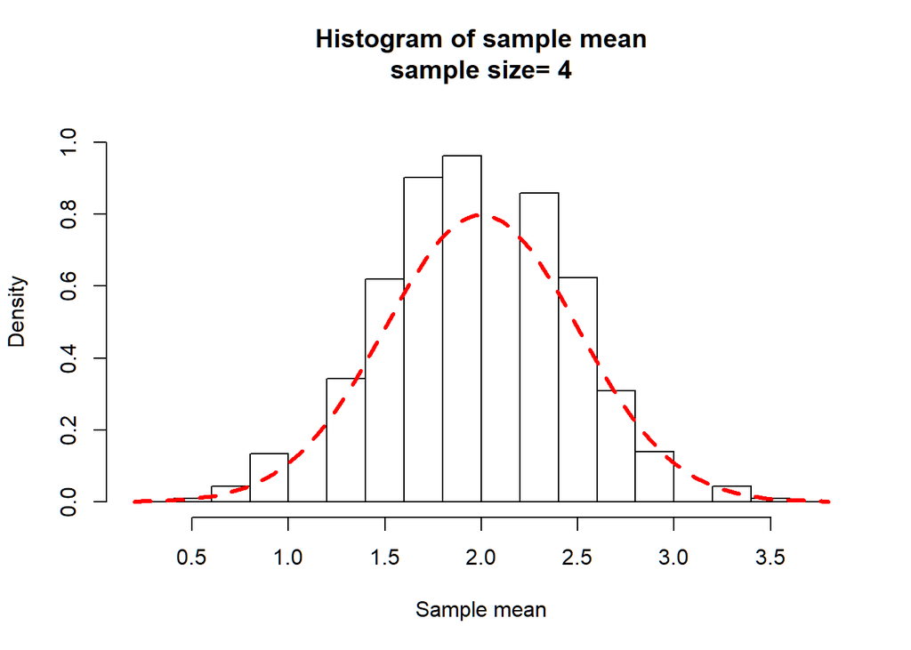

Graph for n=5:

```r
b5 = mycltb(5, 10000, 0.5)
```

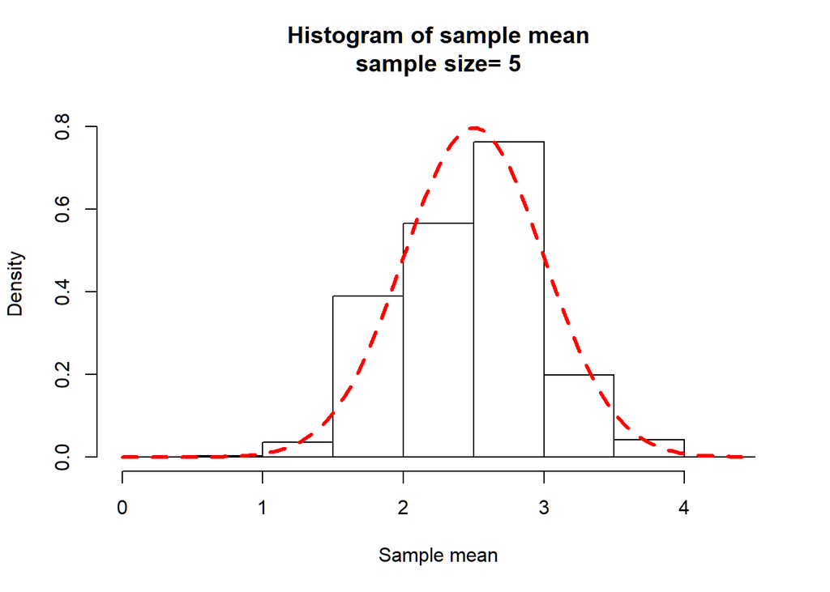

Graph for n=10:

```r
b10 = mycltb(10, 10000, 0.5)
```

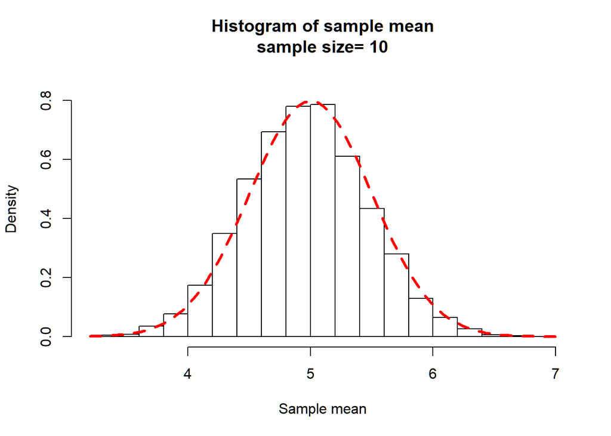

Graph for n=20:

```r
b20 = mycltb(20, 10000, 0.5)
```

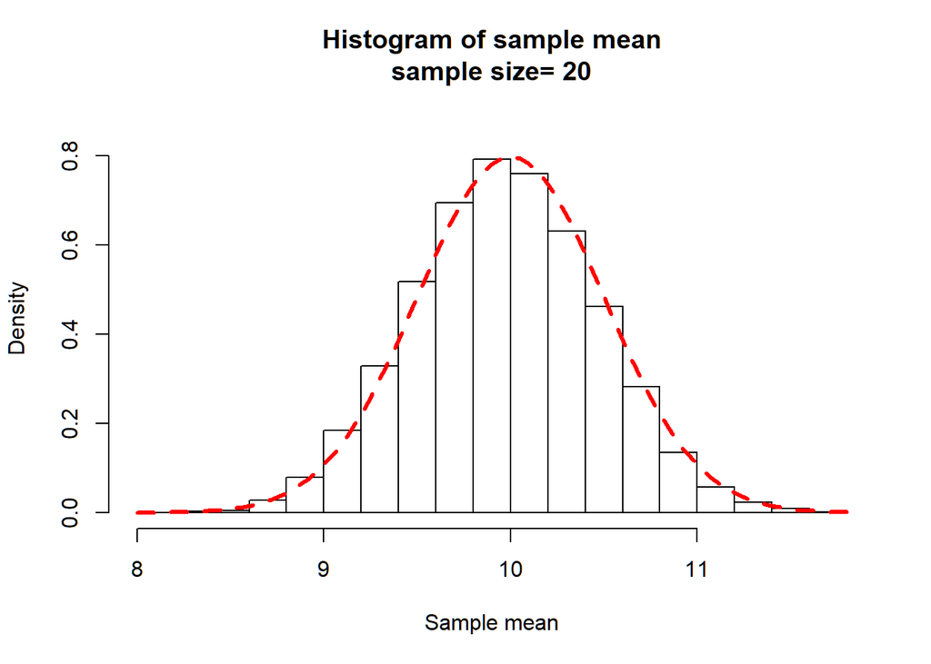

From these three sets of graphs, I conclude that as sample size increases, the sample becomes more normal regardless of the probability of the binomial.

# Task 5

The same sort of function for a poisson distribution is below, called `mycltp`:

```r
mycltp=function(n,iter,lambda=10,...){
  ## r-random sample from the Poisson
  y=rpois(n*iter,lambda=lambda)
  ## Place these numbers into a matrix
  ## The columns will correspond to the iteration and the rows will equal the sample size n
  data=matrix(y,nr=n,nc=iter,byrow=TRUE)
  ## apply the function mean to the columns (2) of the matrix
  ## these are placed in a vector w
  w=apply(data,2,mean)
  ## We will make a histogram of the values in w
  ## How high should we make y axis?
  ## All the values used to make a histogram are placed in param (nothing is plotted yet)
  param=hist(w,plot=FALSE)
  ## Since the histogram will be a density plot we will find the max density

  ymax=max(param$density)
  ## To be on the safe side we will add 10% more to this
  ymax=1.1*ymax

  ## Make a suitable layout for graphing
  layout(matrix(c(1,1,2,3),nr=2,nc=2, byrow=TRUE))

  ## Now we can make the histogram
  hist(w,freq=FALSE,  ylim=c(0,ymax), col=rainbow(max(w)),
  main=paste("Histogram of sample mean","\n", "sample size= ",n," iter=",iter,"   lambda=",lambda,sep=""),
  xlab="Sample mean",...)
  ## add a density curve made from the sample distribution
  #lines(density(w),col="Blue",lwd=3) # add a density plot
  ## Add a theoretical normal curve
  curve(dnorm(x,mean=lambda,sd=sqrt(lambda/n)),add=TRUE,col="Red",lty=2,lwd=3) # add a theoretical   curve

  # Now make a new plot
  # Since y is discrete we should use a barplot
  barplot(table(y)/(n*iter),col=rainbow(max(y)), main="Barplot of sampled y", ylab ="Rel.   Freq",xlab="y" )
  x=0:max(y)
  plot(x,dpois(x,lambda=lambda),type="h",lwd=5,col=rainbow(max(y)),
  main="Probability function for Poisson", ylab="Probability",xlab="y")
}
```

n = 2, lambda = 4:

```r
pois1 = mycltp(n=2, iter=10000, lambda = 4)
```

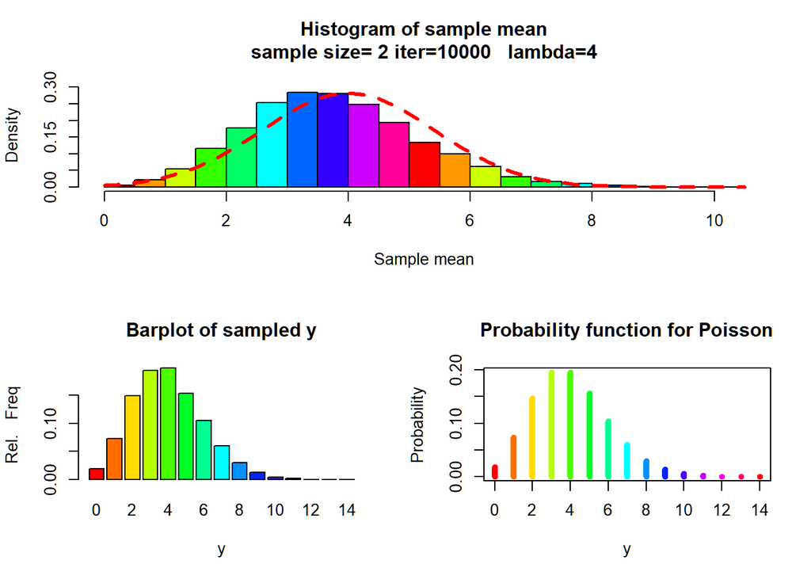

n = 3, lambda = 4:

```r
pois2 = mycltp(n=3, iter=10000, lambda = 4)
```

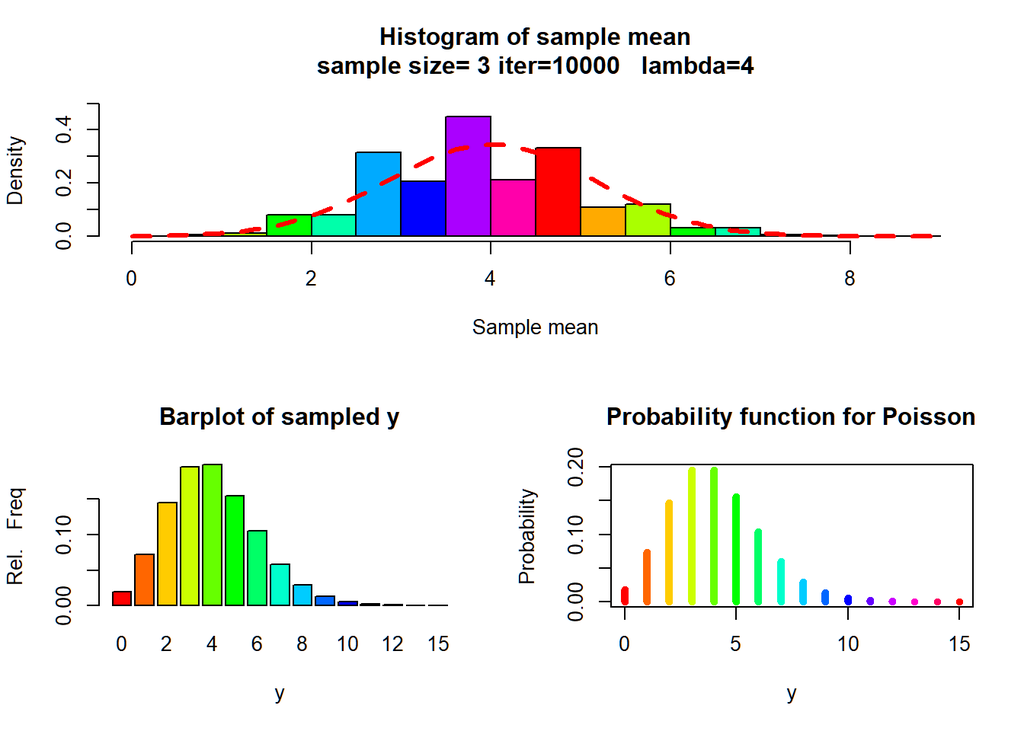

n = 5, lambda = 4:

```r
pois3 = mycltp(n=5, iter=10000, lambda = 4)
```

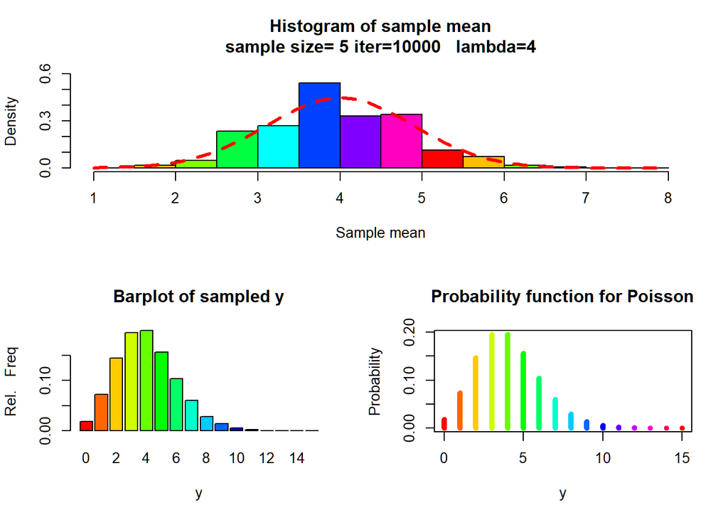

n = 10, lambda = 4:

```r
pois4 = mycltp(n=10, iter=10000, lambda = 4)
```

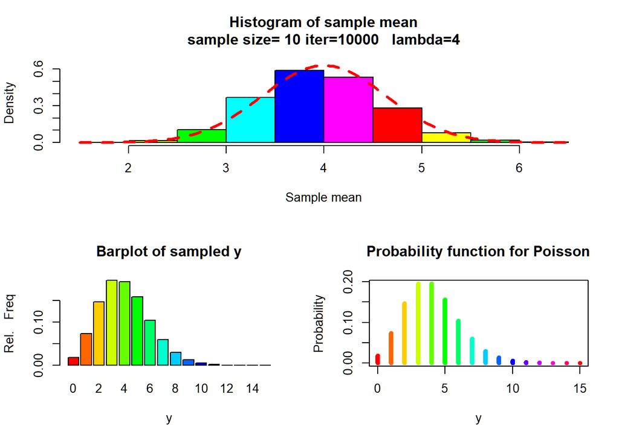

n = 20, lambda = 4:

```r
pois1 = mycltp(n=20, iter=10000, lambda = 4)
```

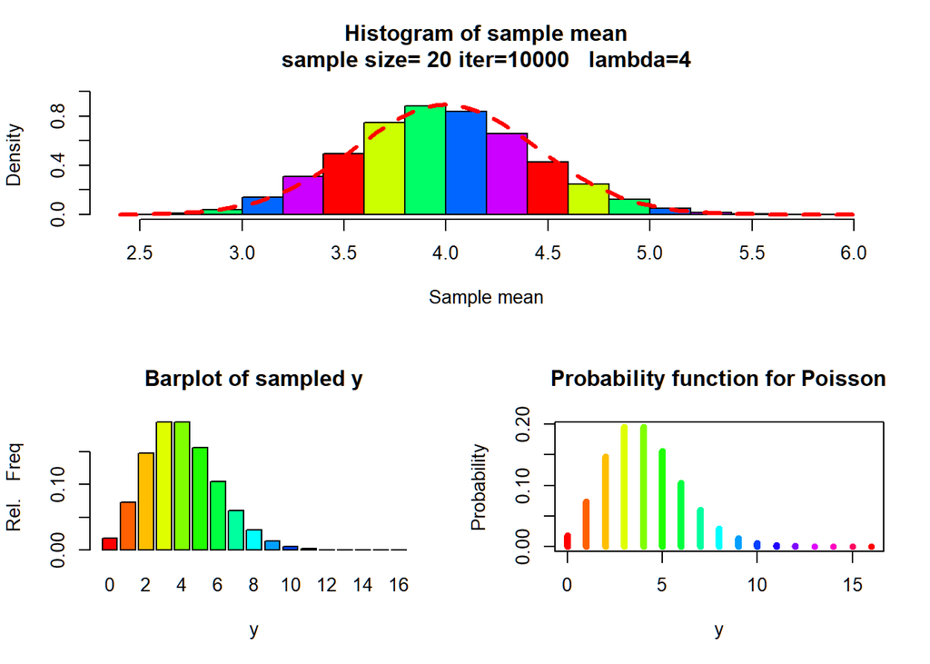

Now, the same sequence will be done with lambda = 10 n = 2, lambda = 10:

```r
pois1 = mycltp(n=2, iter=10000, lambda = 10)
```

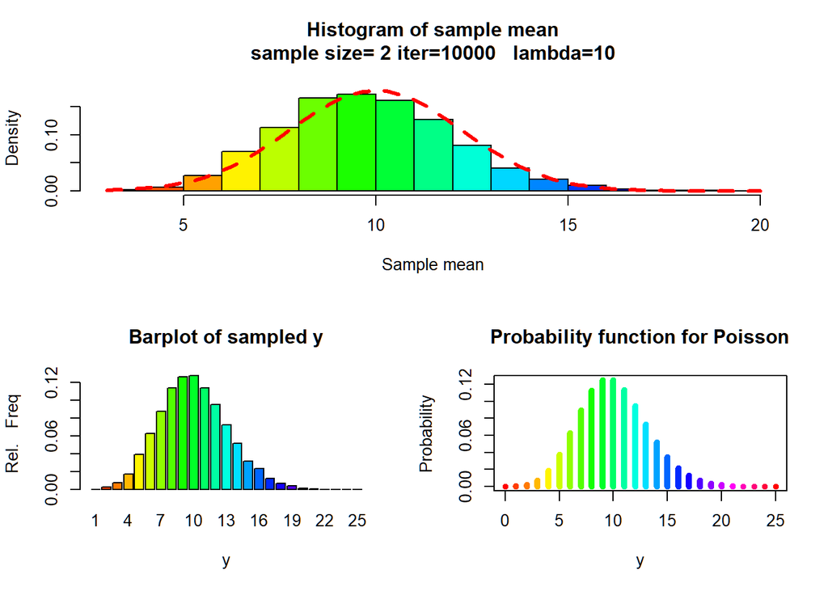

n = 3, lambda = 10:

```r
pois2 = mycltp(n=3, iter=10000, lambda = 10)
```

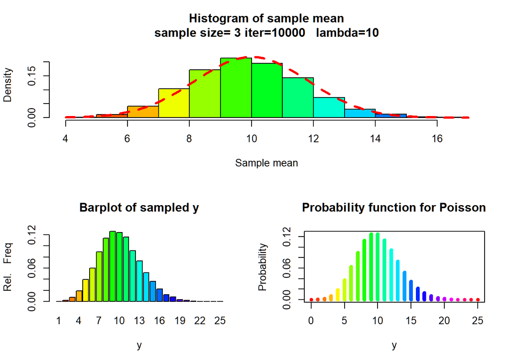

n = 5, lambda = 10:

```r
pois3 = mycltp(n=5, iter=10000, lambda = 10)
```

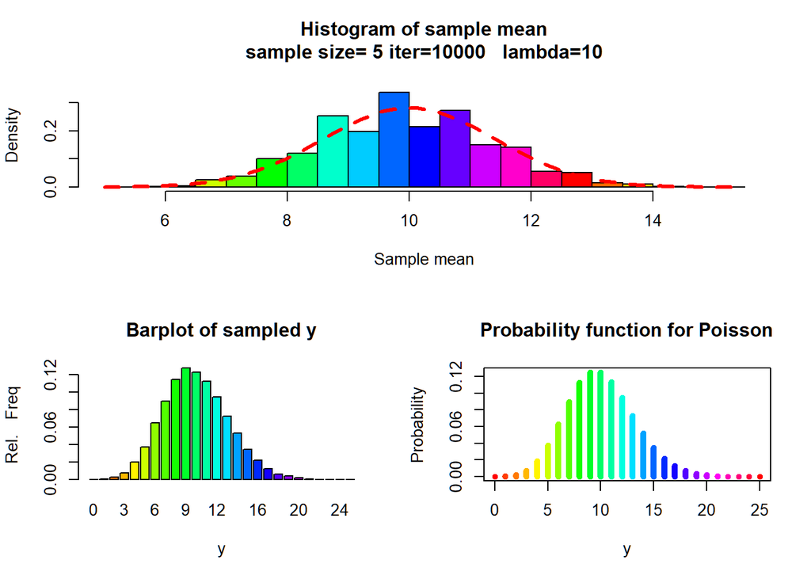

n = 10, lambda = 10:

```r
pois4 = mycltp(n=10, iter=10000, lambda = 10)
```

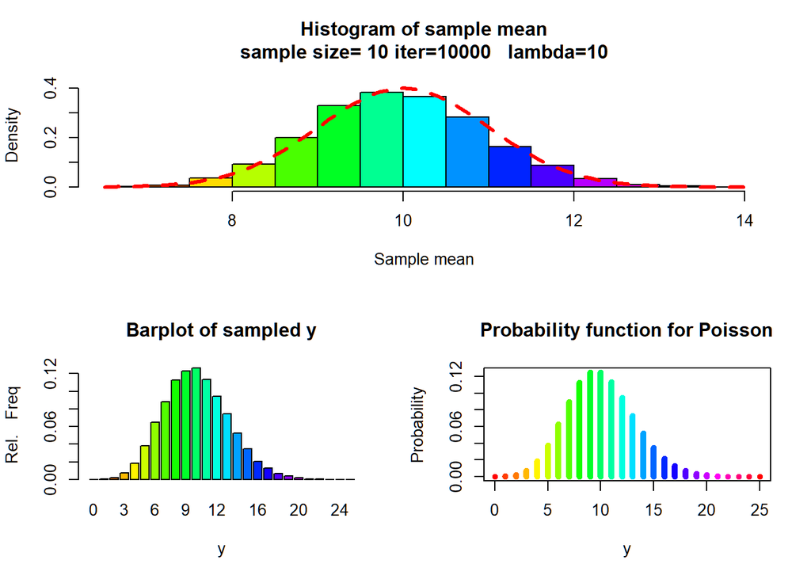

n = 20, lambda = 10:

```r
pois1 = mycltp(n=20, iter=10000, lambda = 10)
```

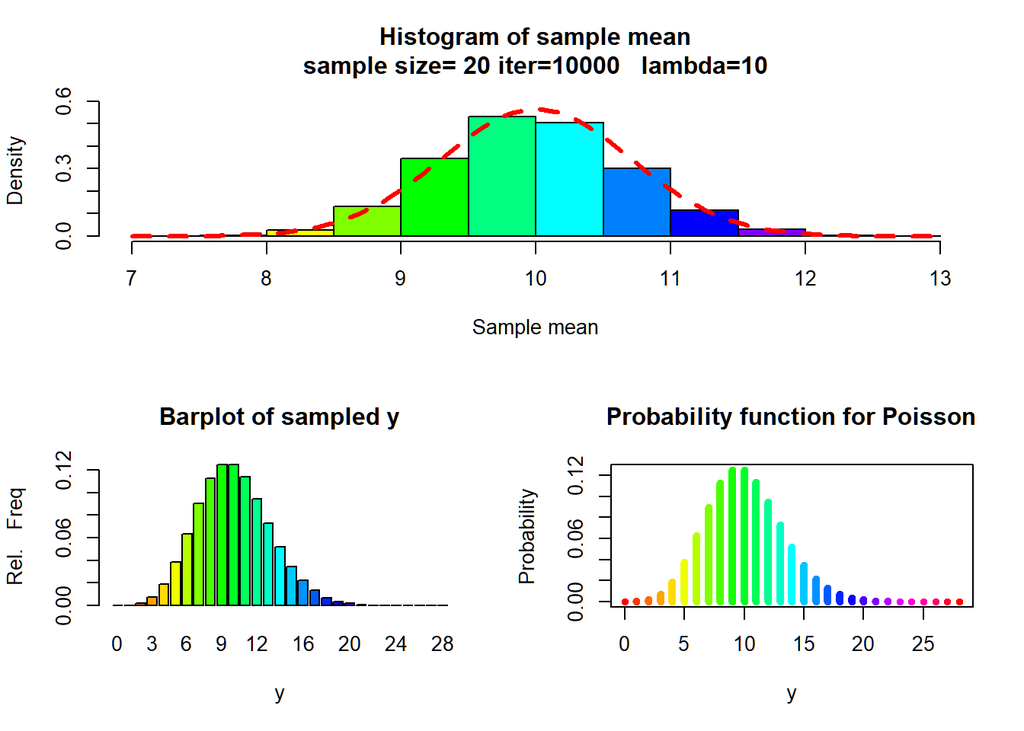

# Task 6

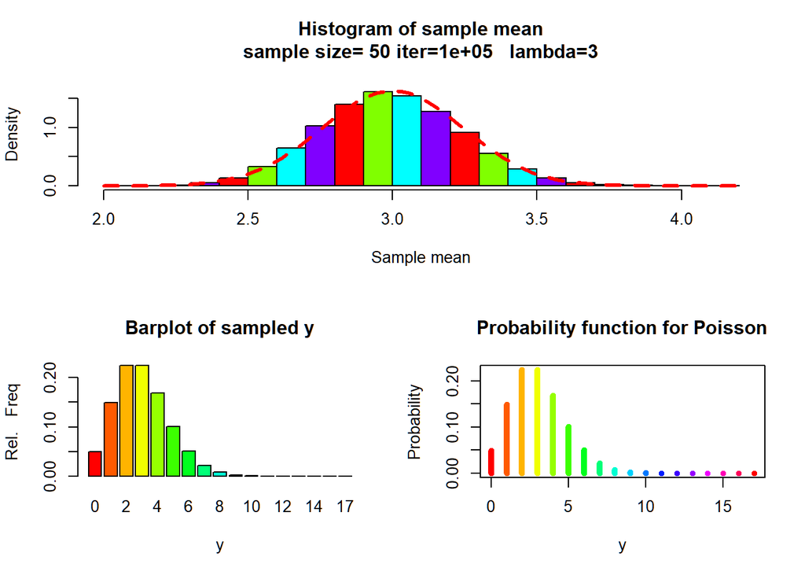

```r
JKleiberPkg::mycltp(50, 100000, 3)
```